# 11 - Introdução a paralelismo - SuperComputação - 2020/2

[figure not shown]

SuperComputação

Igor Montagner, Luciano Soares

2020/2

# 11 - Introdução a Paralelismo

## Comparação de implementações diferentes para o mesmo algoritmo

Nossa aula se inicia examinando o efeito de uma implementação cuidadosa de um algoritmo no tempo de execução final.

```
import subprocess
import time

with open('entradas-busca-local/in-10.txt') as f:
    start = time.perf_counter()
    proc = subprocess.run(['./busca-local'], input=f.read(), text=True, capture_output=True)
    end = time.perf_counter()

    print('Saída:', proc.stdout)
    print('Stderr:', proc.stderr)
    print('Tempo total(s):', end - start)
```

[output not shown]

[output cut: 106 more lines]

Vamos agora praticar usar este snippet para executar nossos testes automaticamente.

Example

Crie uma função `roda_com_entrada(executavel, arquivo_in)` que roda o primeiro argumento usando como entrada o conteúdo do segundo argumento. Teste seu código com o executável `busca-local` e com o arquivo de entrada `entrada-pequena.txt` presente na pasta da aula.

Sua função deverá devolver uma tupla `(stdout,time)` com `stdout` sendo a saída do programa e `time` seu tempo de execução em segundos.

```
import subprocess
import time
def roda_com_entrada(exec, arq):
    with open(arq) as f:
        start = time.perf_counter()
        proc = subprocess.run([exec], input=f.read(), text=True, capture_output=True)
        end = time.perf_counter()

        return proc.stdout, end - start

roda_com_entrada('./bl-ruim', 'entradas-busca-local/in-0.txt')
```

```
('8 0\n4 0 3 2 1 \n', 0.004148643001826713)
```

Com esse código, vamos criar um relatório interativo que roda nossos testes automaticamente e já plota informações prontas para nossas análises. Vamos começar examinando o desempenho do executável `busca-local`.

Example

Rode o `busca-local` com os arquivos de entrada na pasta `entradas-busca-local`. Guarde os tempos em uma lista.

Example

Leia o tamanho das entradas dos arquivos na pasta `entradas-busca-local` e guarde em uma segunda lista.

Example

Plote o tempo de execução pelo tamanho da entrada usando `matplotlib`

```
entradas = [f'entradas-busca-local/in-{i}.txt' for i in range(12)]
tamanhos = []
for i in range(12):
    with open(f'entradas-busca-local/in-{i}.txt') as f:
        tamanhos.append(float(f.readline()))
```

```
tempos_ruins = [roda_com_entrada('./bl-ruim', ent)[1] for ent in entradas]
```

```
tempos_bom = []
for ent in entradas:
    tempos_bom.append(roda_com_entrada('./busca-local', ent)[1])
```

```
import matplotlib.pyplot as plt

print(tamanhos, tempos_bom)

#plt.plot(tamanhos, tempos_bom, label='Professor')
plt.plot(tamanhos, tempos_ruins, color='r', label='Estudante')
plt.title('Desempenho busca local')
plt.xlabel('Tamannho (N)')
plt.ylabel('Tempo (s)')
plt.legend()
```

```
[5.0, 10.0, 15.0, 20.0, 30.0, 40.0, 50.0, 60.0, 70.0, 80.0, 90.0, 100.0] [0.009747421001520706, 0.008420272999501321, 0.012893437000457197, 0.020070746999408584, 0.04817943800298963, 0.11577622099866858, 0.261082938999607, 0.7823042499985604, 1.9667064889981702, 1.7889535520007485, 3.973028257001715…
```

[figure not shown]

O arquivo `busca-local` contém uma implementação cuidadosa da busca local do projeto. Ele não contém nenhuma técnica diferente das apresentadas em aula, mas evita ao máximo operações desnecessárias. Vamos agora comparar os resultados obtidos por ele com sua implementação.

Example

Rode seu a busca local de seu projeto com as mesmas entradas acima e plote os tempos de ambos no mesmo gráfico. Não se esqueça de colocar legendas e título!

```
# seu código aqui
```

Question

Interprete o gráfico que você gerou na linha de cima. Existe diferença entre o tempo gasto pelas duas implementações?

Até agora só testamos eficiência, mas poderia ser interessante testar também a qualidade da solução produzida.

Question

Em qual situação você entende que comparar a qualidade da solução produzida é válido? Como você faria essa comparação? Responda levando em conta

- tamanho das entradas usadas
- quantidade de execuções para cada arquivo de entrada
- quantidade de arquivos para cada tamanho de entrada.

## Expectativas de ganhos com paralelismo

Agora que já conseguimos comparar implementações de um mesmo algoritmo básico, vamos relembrar os tipos de paralelismo vistos em aula:

Tipos de paralelismo

**Dados**: operação (lenta) é feita em paralelo para cada elemento de um conjunto de dados.

**Tarefas**: tarefas não dependentes entre si são executadas em paralelo.

Já vimos em aula que a busca exaustiva é um problema que deveria ser facilmente paralelizável, já que não possui dependência entre as escolhas de um nível da recursão.

Example

Meça o tempo da busca exaustiva do seu projeto para as entradas da pasta `entradas-busca-exaustiva`. Salve em uma lista.

Example

Supondo que sua máquina de testes tenha **8 cores**, qual seria o tempo gasto para cada uma das entradas acima? Salve estes valores em uma nova lista.

Example

Plote abaixo o tempo real do algoritmo sequencial e o tempo esperado do seu projeto se ele fosse paralelizado.

```
# seu código aqui
```

Vamos agora verificar se essa intuição se mantém para uma implementação cuidadosa do algoritmo de busca exaustiva e para uma paralelização bem feita. Os arquivos `busca-exaustiva` e `busca-exaustiva-par` contém essas implementações.

Example

Execute ambos para as entradas da pasta `entradas-busca-exaustiva` e plote os tempos abaixo.

Question

As expectativas que você escreveu na pergunta anterior foram confirmadas? Como você avaliou isso?

Example

O arquivo `busca-branch-and-bound` possui uma implementação sequencial de um bound razoável para o caixeiro viajante. Compare-o com `busca-exaustiva-par`.

Question

Quais foram os resultados da comparação?

```
entrada2s = [f'entradas-busca-exaustiva/in-{i}.txt' for i in range(7)]
tamanhos2 = []
for i in range(7):
    with open(f'entradas-busca-exaustiva/in-{i}.txt') as f:
        tamanhos2.append(float(f.readline()))
```

```
tempos_be = [roda_com_entrada('./busca-exaustiva', ent)[1] for ent in entrada2s]
tempos_be_par = [roda_com_entrada('./busca-exaustiva-par', ent)[1] for ent in entrada2s]
tempos_bound = [roda_com_entrada('./busca-branch-and-bound', ent)[1] for ent in entrada2s]
```

```
plt.plot(tamanhos2, tempos_be, label='exaustivo')
plt.plot(tamanhos2, tempos_be_par, label='paralelo')
plt.plot(tamanhos2, tempos_bound, label='branch and bound')
plt.legend()
plt.title('Desempenho - busca global')
plt.xlabel('Tamanho (N)')
```

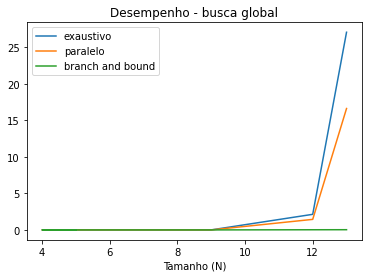

### Número de cores importa?

Vamos agora finalizar nosso estudo verificando se o número de *cores* afeta linearmente o desempenho.

Tip

Para configurar o número de cores usados em `busca-exaustiva-par` usamos a *variável de ambiente* `OMP_NUM_THREADS`

Example

Varia o número de CPUS usadas e verifique com `htop` que a preferência foi respeitada.

Question

Como você usaria o parâmetro `env` de `subprocess.run` para configurar o número de CPUs?

Example

Faça um experimento com `in-6.txt` variando o número de CPUs de `1` até `8` e plote os resultados.

Question

Mais cores sempre ajudam? Como você avalia isto? E se o tamanho do problema for maior? Relacione número de cores, tamanho da entrada e desempenho.